# Predicting the Prices of Homes in Boston

Multiple Linear Regression INSOFE Lab Session

12th Jan 2020

### Agenda

- Get the data
- Ask an interesting question
- Explore the data
- Data Pre-processing
- Model the data
- Evaluation

### Data Description

- The column/variable names’ explanation is given below:
1. **CRIM :** Per capita Crime rate by town
2. **ZN :** Proportion of residential land zoned for lots over 25,000 sq.ft.
3. **INDUS :** Proportion of non-retail business acres per town
4. **CHAS :**_ Charles River dummy variable (= 1 if tract bounds river; 0 otherwise)
5. **NOX :** nitric oxides concentration (parts per 10 million)
6. **RM :** average number of rooms per dwelling
7. **AGE :** proportion of owner-occupied units built prior to 1940
8. **DIS :** weighted distances to five Boston employment centres
9. **RAD :** index of accessibility to radial highways
10. **TAX :** full-value property-tax rate per $10,000
11. **PTRATIO :** pupil-teacher ratio by town
12. **B :** 1000(Bk - 0.63)^2 where Bk is the proportion of African-Americans by town
13. **LSTAT :** Percentage of the population in the lower economic status
14. **MEDV :** Median value of owner-occupied homes in multiples of $1000

**NOTE** Before starting this assignment please remember to clear your environment, you can do that by running the following code chunk ### Clear the environment

```r
rm(list = ls(all=TRUE))
```

### Load the required libraries

```r
library(dplyr)
library(caret)
library(modes)
library(gtools)
```

### Reading & Understanding the Data

- Make sure the dataset is located in your current working directory

```r
housing_data <- read.csv("housing_data.csv",header=T,sep=",")
```

- Use the str() function to get a feel for the dataset.

```r
str(housing_data)
```

```
## 'data.frame':    500 obs. of  14 variables:
##  $ CRIM : num  0.00632 0.02731 0.02729 0.03237 0.06905 ...
##  $ ZN   : num  18 0 0 NA 0 0 12.5 12.5 12.5 12.5 ...
##  $ INDUS: num  2.31 7.07 7.07 2.18 2.18 ...
##  $ CHAS : int  0 0 0 0 0 0 0 0 0 0 ...
##  $ NOX  : num  0.538 0.469 0.469 0.458 0.458 ...
##  $ RM   : num  6.57 6.42 7.18 7 7.15 ...
##  $ AGE  : num  65.2 78.9 61.1 45.8 54.2 ...
##  $ DIS  : num  4.09 4.97 4.97 6.06 6.06 ...
##  $ RAD  : int  1 2 2 3 3 3 5 5 5 5 ...
##  $ TAX  : int  296 242 242 222 222 222 311 311 311 311 ...
##  $ PT   : num  15.3 17.8 17.8 18.7 18.7 ...
##  $ B    : num  NA 397 393 395 397 ...
##  $ LSTAT: num  4.98 9.14 4.03 2.94 5.33 ...
##  $ MV   : num  24 21.6 34.7 33.4 36.2 ...
```

#### Observation:

- The dataset has 500 rows and 13 attributes and one tagret MV.
- CHAS and RAD should be categorical just they are showing the numerical values

### Converting into required Data Types

```r
housing_data$CHAS = as.factor(housing_data$CHAS)
housing_data$RAD = as.factor(housing_data$RAD)
```

### View few rows of data from top and bottom

- Take a look at the data using the “head()” and “tail()” functions

```r
head(housing_data)
```

```
##      CRIM ZN INDUS CHAS   NOX    RM  AGE    DIS RAD TAX   PT      B LSTAT
## 1 0.00632 18  2.31    0 0.538 6.575 65.2 4.0900   1 296 15.3     NA  4.98
## 2 0.02731  0  7.07    0 0.469 6.421 78.9 4.9671   2 242 17.8 396.90  9.14
## 3 0.02729  0  7.07    0 0.469 7.185 61.1 4.9671   2 242 17.8 392.83  4.03
## 4 0.03237 NA  2.18    0 0.458 6.998 45.8 6.0622   3 222 18.7 394.63  2.94
## 5 0.06905  0  2.18    0 0.458 7.147 54.2 6.0622   3 222 18.7 396.90  5.33
## 6 0.02985  0  2.18    0 0.458 6.430 58.7 6.0622   3 222 18.7 394.12  5.21
##     MV
## 1 24.0
## 2 21.6
## 3 34.7
## 4 33.4
## 5 36.2
## 6 28.7
```

```r
tail(housing_data)
```

```
##        CRIM ZN INDUS CHAS   NOX    RM  AGE    DIS RAD TAX   PT      B
## 495 0.22438  0  9.69    0 0.585 6.027 79.7 2.4982   6 391 19.2 396.90
## 496 0.06263  0 11.93    0 0.573 6.593 69.1 2.4786   1 273 21.0 391.99
## 497 0.04527  0 11.93    0 0.573 6.120 76.7 2.2875   1 273 21.0 396.90
## 498 0.06076  0 11.93    0    NA 6.976 91.0 2.1675   1 273 21.0 396.90
## 499 0.10959  0 11.93    0 0.573 6.794 89.3 2.3889   1 273 21.0 393.45
## 500 0.04741  0 11.93    0 0.573 6.030 80.8 2.5050   1 273 21.0 396.90
##     LSTAT   MV
## 495 14.33 16.8
## 496  9.67 22.4
## 497  9.08 20.6
## 498  5.64 23.9
## 499  6.48 22.0
## 500  7.88 11.9
```

### Ask and Explore interesting Questions

# Exploratory Analysis

## Summary Statistics

- Understand the distribution of various variables in the datset using the “summary()” function

```r
summary(housing_data)
```

```
##       CRIM                ZN             INDUS         CHAS
##  Min.   : 0.00632   Min.   :  0.00   Min.   : 0.46   0   :460
##  1st Qu.: 0.08199   1st Qu.:  0.00   1st Qu.: 5.19   1   : 35
##  Median : 0.26169   Median :  0.00   Median : 9.69   NA's:  5
##  Mean   : 3.65532   Mean   : 11.25   Mean   :11.12
##  3rd Qu.: 3.67822   3rd Qu.: 12.50   3rd Qu.:18.10
##  Max.   :88.97620   Max.   :100.00   Max.   :27.74
##  NA's   :7          NA's   :7        NA's   :4
##       NOX               RM             AGE              DIS
##  Min.   :0.3850   Min.   :3.561   Min.   :  2.90   Min.   : 1.130
##  1st Qu.:0.4482   1st Qu.:5.885   1st Qu.: 44.40   1st Qu.: 2.097
##  Median :0.5380   Median :6.209   Median : 77.70   Median : 3.191
##  Mean   :0.5538   Mean   :6.289   Mean   : 68.58   Mean   : 3.785
##  3rd Qu.:0.6240   3rd Qu.:6.629   3rd Qu.: 94.10   3rd Qu.: 5.118
##  Max.   :0.8710   Max.   :8.780   Max.   :100.00   Max.   :12.127
##  NA's   :6        NA's   :4       NA's   :3        NA's   :4
##       RAD           TAX              PT              B
##  24     :129   Min.   :187.0   Min.   :12.60   Min.   :  0.32
##  5      :111   1st Qu.:279.0   1st Qu.:17.40   1st Qu.:375.30
##  4      :109   Median :330.0   Median :19.10   Median :391.34
##  3      : 36   Mean   :407.5   Mean   :18.47   Mean   :356.60
##  6      : 26   3rd Qu.:666.0   3rd Qu.:20.20   3rd Qu.:396.21
##  (Other): 84   Max.   :711.0   Max.   :22.00   Max.   :396.90
##  NA's   :  5   NA's   :6       NA's   :9       NA's   :4
##      LSTAT             MV
##  Min.   : 1.73   Min.   : 5.00
##  1st Qu.: 6.95   1st Qu.:17.07
##  Median :11.43   Median :21.20
##  Mean   :12.65   Mean   :22.56
##  3rd Qu.:16.95   3rd Qu.:25.00
##  Max.   :37.97   Max.   :50.00
##  NA's   :6
```

#### Observation

- There are NA values in all the attributes except the target column.

### Data Pre-processing

- Today we will impute missing values and standardize the data **after** splitting the data into train and test sets

## Train/Test Split

- 70/30 - Train/Test split

```r
set.seed(29)

# the "sample()" function helps us to randomly sample 70% of the row indices of the dataset

train_rows <- sample(x = 1:nrow(housing_data), size = 0.7*nrow(housing_data))

# We use the above indices to subset the train and test sets from the data

train_data <- housing_data[train_rows, ]

test_data <- housing_data[-train_rows, ]
```

## Missing Values imputation

```r
#install.packages("caret")
sum(is.na(train_data))
```

```
## [1] 52
```

```r
library(caret)

imputer_values <- preProcess(x = train_data, method = "medianImpute")

sum(is.na(train_data))
```

```
## [1] 52
```

```r
train_data <- predict(object = imputer_values, newdata = train_data)

sum(is.na(train_data))
```

```
## [1] 7
```

```r
sum(is.na(test_data))
```

```
## [1] 18
```

```r
test_data <- predict(object = imputer_values, newdata = test_data)

sum(is.na(test_data))
```

```
## [1] 3
```

### Imputing the categorical values with the mode

```r
library(DMwR)
train_data = centralImputation(train_data)
test_data = centralImputation(test_data)
```

### Scatter Plots

- A few bi-variate relationships are plotted below, but you are encouraged to explore the dataset in more detail

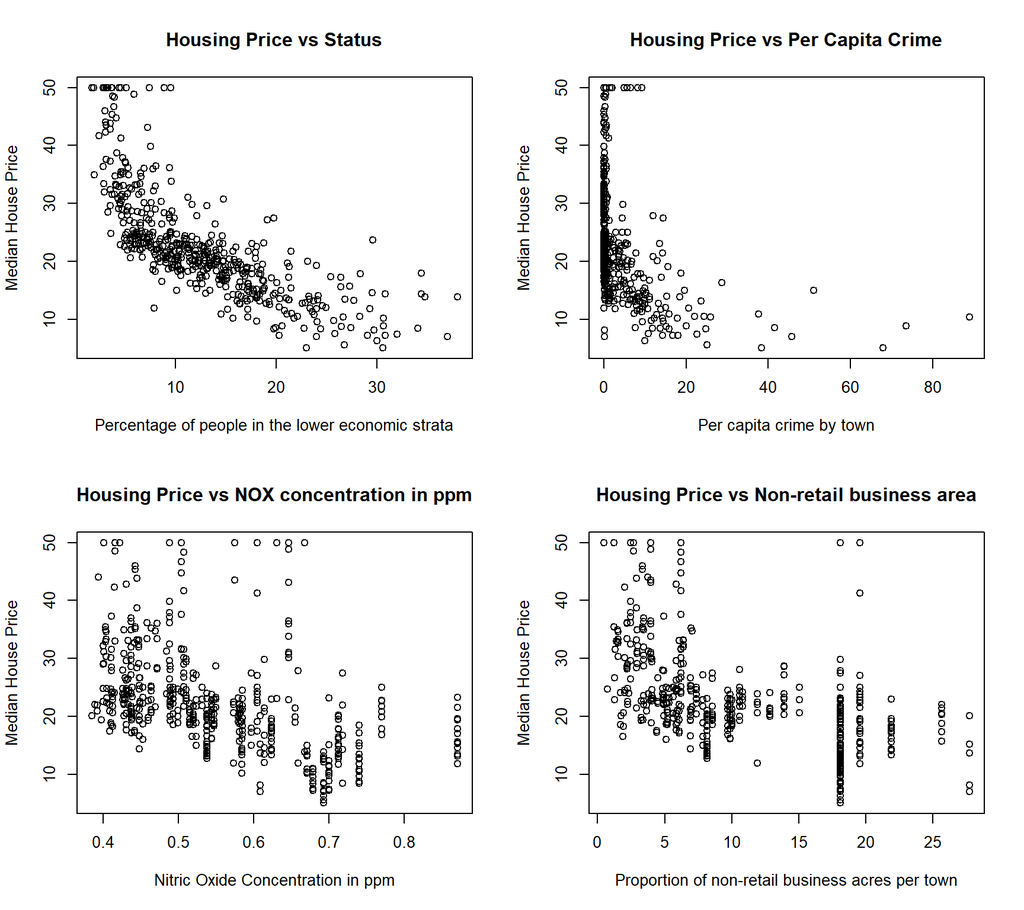

```r
par(mfrow = c(2,2))

plot(housing_data$LSTAT, housing_data$MV, ylab = "Median House Price", xlab = "Percentage of people in the lower economic strata", main = "Housing Price vs Status")

plot(housing_data$CRIM, housing_data$MV, ylab = "Median House Price", xlab = "Per capita crime by town", main = "Housing Price vs Per Capita Crime")

plot(housing_data$NOX, housing_data$MV, ylab = "Median House Price", xlab = "Nitric Oxide Concentration in ppm", main = "Housing Price vs NOX concentration in ppm")

plot(housing_data$INDUS, housing_data$MV, ylab = "Median House Price", xlab = "Proportion of non-retail business acres per town", main = "Housing Price vs Non-retail business area")
```

### Split the numerical and categorical attributes

```r
cols = colnames(train_data[,!names(train_data)%in%c("MV")])
numAttr = c()
catAttr = c()
for (i in cols){
  if (is.numeric(train_data[,c(i)])!=T){
    catAttr = c(catAttr,i)
  }else
  numAttr = c(numAttr,i)
}
cat("\n The Categorical Attributes =",catAttr)
```

```
##
##  The Categorical Attributes = CHAS RAD
```

```r
cat("\n The Numerical Attributes =  ",numAttr)
```

```
##
##  The Numerical Attributes =   CRIM ZN INDUS NOX RM AGE DIS TAX PT B LSTAT
```

### Correlation Plot for Numerical Attributes

- Let’s have a look at the various correlations between the numerical variables in the dataset

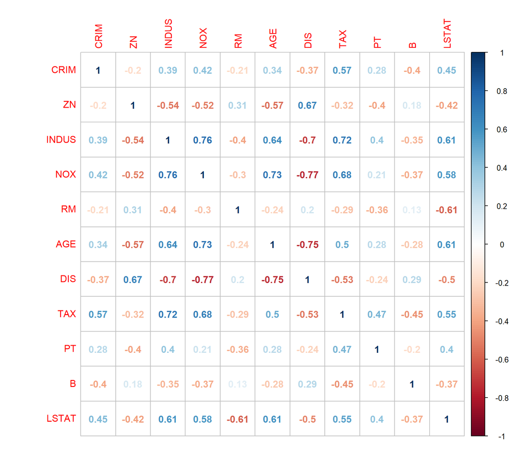

```r
#install.packages("corrplot")
library(corrplot)
corrplot(cor(housing_data[,numAttr], use = "complete.obs"), method = "number")
```

#### Observation: * There are correlations which have high magnitude but with both directions * Example NOX and INDUS are positively correlated,DIS and Age * LSTAT and MV are having strong ngeative correlation * “Correlation is not a causation” we have to check for the mutual effects of the numerical attributes and hence we are not removing any attribute here.

### Chisquare test on Categorical Attributes

```r
contingency = table(train_data$CHAS,train_data$RAD)
chisq.test(contingency)
```

```
##
##  Pearson's Chi-squared test
##
## data:  contingency
## X-squared = 7.869, df = 8, p-value = 0.4464
```

#### Observation:

- Null Hypothesis in Chisquare test for independence is the two attributes are independent.
- Since pValue is 0.44 which is greater than 0.05 we have to accept the null hypothesis that they are independent.

### Standardizing the Data

- We will use the Caret pakcage to standardize the data after the split using the **“preProcess()”** function
- It saves the metrics such as mean and standard deviation used for calculating the standardized value by creating a model object
- We can then use the model object in the **“predict()”** function to standardize any other unseen dataset with the same distribuiton and variables

```r
library(caret)

# The "preProcess()" function creates a model object required for standardizing unseen data

# Do not standardize the target variable

std_model <- preProcess(train_data[, numAttr], method = c("center", "scale"))

# The predict() function is used to standardize any other unseen data

train_data[, numAttr] <- predict(object = std_model, newdata = train_data[, numAttr])

test_data[, numAttr] <- predict(object = std_model, newdata = test_data[,numAttr])
```

# Modelling the Data

## Basic Model

- The “.” adds all the variables other than the response variable while building the model.

```r
model_basic <- lm(formula = MV~. , data = train_data)

summary(model_basic)
```

```
##
## Call:
## lm(formula = MV ~ ., data = train_data)
##
## Residuals:
##      Min       1Q   Median       3Q      Max
## -18.3788  -2.6190  -0.6276   1.5379  25.4254
##
## Coefficients:
##             Estimate Std. Error t value Pr(>|t|)
## (Intercept) 18.10122    1.35778  13.331  < 2e-16 ***
## CRIM        -1.09414    0.32015  -3.418 0.000711 ***
## ZN           1.08665    0.36131   3.008 0.002836 **
## INDUS        0.02428    0.47564   0.051 0.959321
## CHAS1        2.57770    0.95136   2.709 0.007092 **
## NOX         -1.48224    0.51580  -2.874 0.004321 **
## RM           3.36661    0.34502   9.758  < 2e-16 ***
## AGE         -0.43855    0.41768  -1.050 0.294505
## DIS         -2.89453    0.49077  -5.898 9.14e-09 ***
## RAD2         3.27968    1.72926   1.897 0.058759 .
## RAD3         5.51209    1.61389   3.415 0.000717 ***
## RAD4         3.43929    1.41865   2.424 0.015874 *
## RAD5         3.80550    1.44456   2.634 0.008828 **
## RAD6         1.83032    1.78434   1.026 0.305753
## RAD7         5.75174    1.93435   2.973 0.003162 **
## RAD8         6.53148    1.98112   3.297 0.001084 **
## RAD24        6.57075    1.88431   3.487 0.000555 ***
## TAX         -0.62081    0.64250  -0.966 0.334636
## PT          -1.59403    0.35227  -4.525 8.45e-06 ***
## B            1.00747    0.27798   3.624 0.000336 ***
## LSTAT       -3.43079    0.40798  -8.409 1.27e-15 ***
## ---
## Signif. codes:  0 '***' 0.001 '**' 0.01 '*' 0.05 '.' 0.1 ' ' 1
##
## Residual standard error: 4.607 on 329 degrees of freedom
## Multiple R-squared:  0.7622, Adjusted R-squared:  0.7477
## F-statistic: 52.72 on 20 and 329 DF,  p-value: < 2.2e-16
```

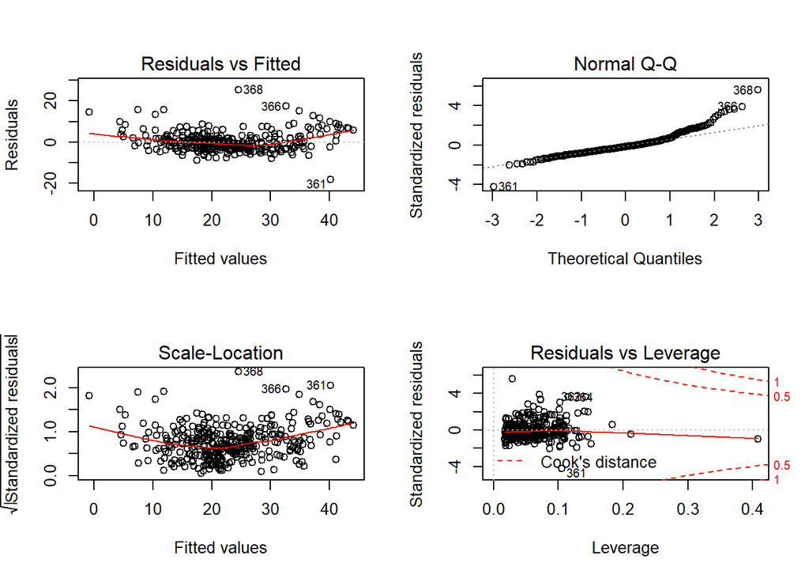

```r
par(mfrow = c(2,2))

plot(model_basic)
```

## stepAIC model

- “stepAIC()” is a function in the MASS package
- stepAIC uses AIC (Akaike information criterion) to either drop variables (“backward” direction) or add variables (“forward” direction) from the model

```r
library(MASS)
model_aic <- stepAIC(model_basic, direction = "both")
```

```
## Start:  AIC=1089.71
## MV ~ CRIM + ZN + INDUS + CHAS + NOX + RM + AGE + DIS + RAD +
##     TAX + PT + B + LSTAT
##
##         Df Sum of Sq    RSS    AIC
## - INDUS  1      0.06 6984.1 1087.7
## - TAX    1     19.82 7003.8 1088.7
## - AGE    1     23.40 7007.4 1088.9
## <none>               6984.0 1089.7
## - CHAS   1    155.84 7139.9 1095.4
## - NOX    1    175.30 7159.3 1096.4
## - ZN     1    192.02 7176.0 1097.2
## - CRIM   1    247.94 7231.9 1099.9
## - RAD    8    570.61 7554.6 1101.2
## - B      1    278.83 7262.8 1101.4
## - PT     1    434.66 7418.7 1108.8
## - DIS    1    738.41 7722.4 1122.9
## - LSTAT  1   1501.14 8485.1 1155.8
## - RM     1   2021.16 9005.2 1176.7
##
## Step:  AIC=1087.71
## MV ~ CRIM + ZN + CHAS + NOX + RM + AGE + DIS + RAD + TAX + PT +
##     B + LSTAT
##
##         Df Sum of Sq    RSS    AIC
## - TAX    1     21.83 7005.9 1086.8
## - AGE    1     23.38 7007.4 1086.9
## <none>               6984.1 1087.7
## + INDUS  1      0.06 6984.0 1089.7
## - CHAS   1    158.67 7142.7 1093.6
## - NOX    1    184.13 7168.2 1094.8
## - ZN     1    193.84 7177.9 1095.3
## - CRIM   1    248.48 7232.5 1097.9
## - B      1    279.05 7263.1 1099.4
## - RAD    8    576.53 7560.6 1099.5
## - PT     1    435.18 7419.2 1106.9
## - DIS    1    790.95 7775.0 1123.3
## - LSTAT  1   1503.94 8488.0 1154.0
## - RM     1   2059.26 9043.3 1176.2
##
```

[output cut: 23 more lines]

```
##         Df Sum of Sq    RSS    AIC
## <none>               7029.7 1086.0
## + AGE    1     23.76 7005.9 1086.8
## + TAX    1     22.21 7007.4 1086.9
## + INDUS  1      2.27 7027.4 1087.9
## - CHAS   1    160.36 7190.0 1091.9
## - ZN     1    200.89 7230.5 1093.8
## - CRIM   1    255.70 7285.4 1096.5
## - RAD    8    557.82 7587.5 1096.7
## - NOX    1    280.06 7309.7 1097.7
## - B      1    297.23 7326.9 1098.5
## - PT     1    486.81 7516.5 1107.4
## - DIS    1    785.58 7815.2 1121.1
## - LSTAT  1   1745.25 8774.9 1161.6
## - RM     1   2054.28 9083.9 1173.7
```

```r
summary(model_aic)
```

```
##
## Call:
## lm(formula = MV ~ CRIM + ZN + CHAS + NOX + RM + DIS + RAD + PT +
##     B + LSTAT, data = train_data)
##
## Residuals:
##      Min       1Q   Median       3Q      Max
## -18.3752  -2.7077  -0.7138   1.5780  25.0273
##
## Coefficients:
##             Estimate Std. Error t value Pr(>|t|)
## (Intercept)  18.3197     1.3280  13.795  < 2e-16 ***
## CRIM         -1.1083     0.3189  -3.475 0.000578 ***
## ZN            1.0994     0.3569   3.080 0.002241 **
## CHAS1         2.5942     0.9427   2.752 0.006248 **
## NOX          -1.7178     0.4723  -3.637 0.000320 ***
## RM            3.3341     0.3385   9.850  < 2e-16 ***
## DIS          -2.7389     0.4497  -6.091 3.10e-09 ***
## RAD2          3.4644     1.6926   2.047 0.041464 *
## RAD3          5.7291     1.6010   3.578 0.000397 ***
## RAD4          3.4944     1.4114   2.476 0.013789 *
## RAD5          3.7568     1.4410   2.607 0.009544 **
## RAD6          1.7198     1.7566   0.979 0.328264
## RAD7          5.6924     1.9275   2.953 0.003368 **
## RAD8          6.3622     1.9690   3.231 0.001356 **
## RAD24         5.6815     1.5940   3.564 0.000418 ***
## PT           -1.6668     0.3476  -4.795 2.46e-06 ***
## B             1.0335     0.2758   3.747 0.000211 ***
## LSTAT        -3.5563     0.3917  -9.079  < 2e-16 ***
## ---
## Signif. codes:  0 '***' 0.001 '**' 0.01 '*' 0.05 '.' 0.1 ' ' 1
##
## Residual standard error: 4.601 on 332 degrees of freedom
## Multiple R-squared:  0.7606, Adjusted R-squared:  0.7484
## F-statistic: 62.05 on 17 and 332 DF,  p-value: < 2.2e-16
```

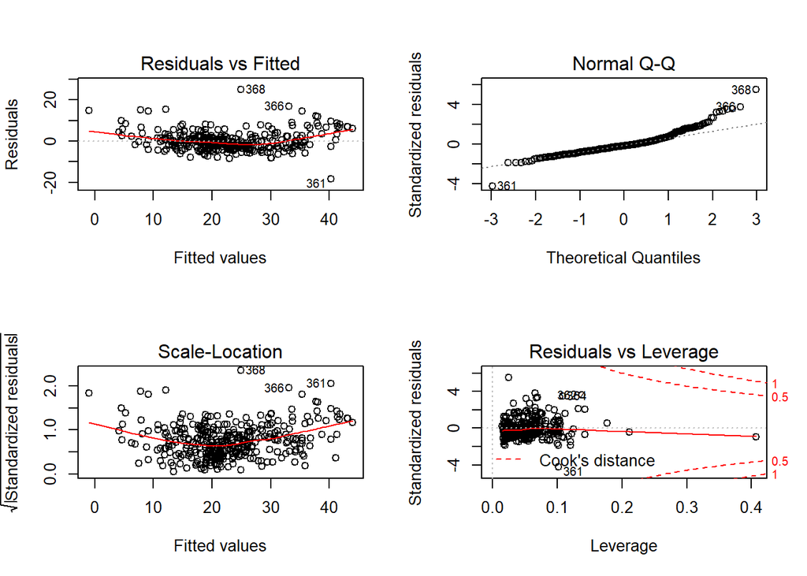

```r
par(mfrow = c(2,2))

plot(model_aic)
```

## Modifying the Model with the VIF

**Variance Inflation Factor :**

$$VIF_{k} = \dfrac{1}{1 - R_{k}^2}$$

$R_{k}^2$ is the R^2-value obtained by regressing the kth predictor on the remaining predictors. VIF gives us an idea of multi-collinearity

- Every explanatory variable would have a VIF score
- A VIF > 4 means that there are signs of multi-collinearity and anything greater than 10 means that an explanatory variable should be dropped
- We use the “vif()” function from the car package.

```r
library(car)
vif(model_basic)
```

```
##            GVIF Df GVIF^(1/(2*Df))
## CRIM   1.685107  1        1.298117
## ZN     2.146190  1        1.464988
## INDUS  3.719421  1        1.928580
## CHAS   1.098320  1        1.048008
## NOX    4.373953  1        2.091400
## RM     1.957091  1        1.398961
## AGE    2.868115  1        1.693551
## DIS    3.959871  1        1.989942
## RAD   13.387730  8        1.176032
## TAX    6.786816  1        2.605152
## PT     2.040175  1        1.428347
## B      1.270426  1        1.127132
## LSTAT  2.736483  1        1.654232
```

```r
vif(model_aic)
```

```
##           GVIF Df GVIF^(1/(2*Df))
## CRIM  1.676640  1        1.294852
## ZN    2.099703  1        1.449035
## CHAS  1.081064  1        1.039742
## NOX   3.677052  1        1.917564
## RM    1.888539  1        1.374241
## DIS   3.332652  1        1.825555
## RAD   5.323023  8        1.110158
## PT    1.991726  1        1.411285
## B     1.254126  1        1.119878
## LSTAT 2.529083  1        1.590309
```

```r
model3 <- lm(formula = MV ~ CRIM + ZN + CHAS + NOX + RM + DIS + RAD + PT + B + LSTAT, data = train_data)

summary(model3)
```

```
##
## Call:
## lm(formula = MV ~ CRIM + ZN + CHAS + NOX + RM + DIS + RAD + PT +
##     B + LSTAT, data = train_data)
##
## Residuals:
##      Min       1Q   Median       3Q      Max
## -18.3752  -2.7077  -0.7138   1.5780  25.0273
##
## Coefficients:
##             Estimate Std. Error t value Pr(>|t|)
## (Intercept)  18.3197     1.3280  13.795  < 2e-16 ***
## CRIM         -1.1083     0.3189  -3.475 0.000578 ***
## ZN            1.0994     0.3569   3.080 0.002241 **
## CHAS1         2.5942     0.9427   2.752 0.006248 **
## NOX          -1.7178     0.4723  -3.637 0.000320 ***
## RM            3.3341     0.3385   9.850  < 2e-16 ***
## DIS          -2.7389     0.4497  -6.091 3.10e-09 ***
## RAD2          3.4644     1.6926   2.047 0.041464 *
## RAD3          5.7291     1.6010   3.578 0.000397 ***
## RAD4          3.4944     1.4114   2.476 0.013789 *
## RAD5          3.7568     1.4410   2.607 0.009544 **
## RAD6          1.7198     1.7566   0.979 0.328264
## RAD7          5.6924     1.9275   2.953 0.003368 **
## RAD8          6.3622     1.9690   3.231 0.001356 **
## RAD24         5.6815     1.5940   3.564 0.000418 ***
## PT           -1.6668     0.3476  -4.795 2.46e-06 ***
## B             1.0335     0.2758   3.747 0.000211 ***
## LSTAT        -3.5563     0.3917  -9.079  < 2e-16 ***
## ---
## Signif. codes:  0 '***' 0.001 '**' 0.01 '*' 0.05 '.' 0.1 ' ' 1
##
## Residual standard error: 4.601 on 332 degrees of freedom
## Multiple R-squared:  0.7606, Adjusted R-squared:  0.7484
## F-statistic: 62.05 on 17 and 332 DF,  p-value: < 2.2e-16
```

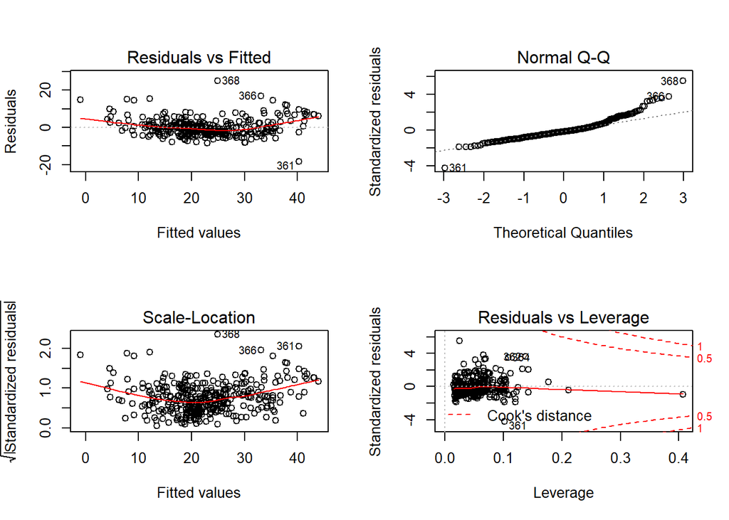

```r
par(mfrow = c(2,2))

plot(model3)
```

```r
vif(model3)
```

```
##           GVIF Df GVIF^(1/(2*Df))
## CRIM  1.676640  1        1.294852
## ZN    2.099703  1        1.449035
## CHAS  1.081064  1        1.039742
## NOX   3.677052  1        1.917564
## RM    1.888539  1        1.374241
## DIS   3.332652  1        1.825555
## RAD   5.323023  8        1.110158
## PT    1.991726  1        1.411285
## B     1.254126  1        1.119878
## LSTAT 2.529083  1        1.590309
```

# Evaluation and Selection of Model

## Picking the Right Model

# Communication

## Prediction

Predict the Housing prices of the unseen boston housing data, using the chosen model.

```r
preds_model <- predict(model3, test_data[, !(names(test_data) %in% c("MV"))])
```

## Performance Metrics

### Error Metrics for Regression

- Mean Absolute Error (MAE):

$$MAE = \dfrac{1}{n}\times|\sum_{i = 1}^{n}y_{i} - \hat{y_{i}}|$$

- Mean Squared Error (MSE):

$$MSE = \dfrac{1}{n}\times(\sum_{i = 1}^{n}y_{i} - \hat{y_{i}})^2$$

- Root Mean Squared Error (RMSE):

$$RMSE = \sqrt{\dfrac{1}{n}\times(\sum_{i = 1}^{n}y_{i} - \hat{y_{i}})^2}$$

- Mean Absolute Percentage Error (MAPE):

$$MAPE = \dfrac{100}{n}\times\mid\dfrac{\sum_{i = 1}^{n}y_{i} - \hat{y_{i}}}{y_{i}}\mid$$

### Report Performance Metrics

- Report performance metrics obtained by using the chosen model on the test data

```r
library(DMwR)

regr.eval(test_data$MV, preds_model)
```

```
##        mae        mse       rmse       mape
##  3.6081411 28.5712567  5.3452088  0.2024455
```